# Predict Bike Sharing Demand with AutoGluon Template

### Download and explore dataset

### Go to the bike sharing demand competition and agree to the terms

```python
# Download the dataset, it will be in a .zip file so you'll need to unzip it as well.
!kaggle competitions download -c bike-sharing-demand
# If you already downloaded it you can use the -o command to overwrite the file
!unzip -o bike-sharing-demand.zip
```

```
Downloading bike-sharing-demand.zip to /content

  0% 0.00/189k [00:00<?, ?B/s]

100% 189k/189k [00:00<00:00, 39.5MB/s]
Archive:  bike-sharing-demand.zip
  inflating: sampleSubmission.csv
  inflating: test.csv
  inflating: train.csv
```

```python
import pandas as pd
import numpy as np
import matplotlib.pyplot as plt
%matplotlib inline
from autogluon.tabular import TabularPredictor
```

```python
# Create the train dataset in pandas by reading the csv
# Set the parsing of the datetime column so you can use some of the `dt` features in pandas later
train = pd.read_csv('train.csv')
train.drop(['casual', 'registered'], axis=1, inplace=True)
train.head()
```

|  | datetime | season | holiday | workingday | weather | temp | atemp | humidity | windspeed | count |
| --- | --- | --- | --- | --- | --- | --- | --- | --- | --- | --- |
| 0 | 2011-01-01 00:00:00 | 1 | 0 | 0 | 1 | 9.84 | 14.395 | 81 | 0.0 | 16 |
| 1 | 2011-01-01 01:00:00 | 1 | 0 | 0 | 1 | 9.02 | 13.635 | 80 | 0.0 | 40 |
| 2 | 2011-01-01 02:00:00 | 1 | 0 | 0 | 1 | 9.02 | 13.635 | 80 | 0.0 | 32 |
| 3 | 2011-01-01 03:00:00 | 1 | 0 | 0 | 1 | 9.84 | 14.395 | 75 | 0.0 | 13 |
| 4 | 2011-01-01 04:00:00 | 1 | 0 | 0 | 1 | 9.84 | 14.395 | 75 | 0.0 | 1 |

```python
# Simple output of the train dataset to view some of the min/max/varition of the dataset features.
train.describe()
```

|  | season | holiday | workingday | weather | temp | atemp | humidity | windspeed | count |
| --- | --- | --- | --- | --- | --- | --- | --- | --- | --- |
| count | 10886.000000 | 10886.000000 | 10886.000000 | 10886.000000 | 10886.00000 | 10886.000000 | 10886.000000 | 10886.000000 | 10886.000000 |
| mean | 2.506614 | 0.028569 | 0.680875 | 1.418427 | 20.23086 | 23.655084 | 61.886460 | 12.799395 | 191.574132 |
| std | 1.116174 | 0.166599 | 0.466159 | 0.633839 | 7.79159 | 8.474601 | 19.245033 | 8.164537 | 181.144454 |
| min | 1.000000 | 0.000000 | 0.000000 | 1.000000 | 0.82000 | 0.760000 | 0.000000 | 0.000000 | 1.000000 |
| 25% | 2.000000 | 0.000000 | 0.000000 | 1.000000 | 13.94000 | 16.665000 | 47.000000 | 7.001500 | 42.000000 |
| 50% | 3.000000 | 0.000000 | 1.000000 | 1.000000 | 20.50000 | 24.240000 | 62.000000 | 12.998000 | 145.000000 |
| 75% | 4.000000 | 0.000000 | 1.000000 | 2.000000 | 26.24000 | 31.060000 | 77.000000 | 16.997900 | 284.000000 |
| max | 4.000000 | 1.000000 | 1.000000 | 4.000000 | 41.00000 | 45.455000 | 100.000000 | 56.996900 | 977.000000 |

```python
# Create the test pandas dataframe in pandas by reading the csv, remember to parse the datetime!
test = pd.read_csv('test.csv')
test.head()
```

|  | datetime | season | holiday | workingday | weather | temp | atemp | humidity | windspeed |
| --- | --- | --- | --- | --- | --- | --- | --- | --- | --- |
| 0 | 2011-01-20 00:00:00 | 1 | 0 | 1 | 1 | 10.66 | 11.365 | 56 | 26.0027 |
| 1 | 2011-01-20 01:00:00 | 1 | 0 | 1 | 1 | 10.66 | 13.635 | 56 | 0.0000 |
| 2 | 2011-01-20 02:00:00 | 1 | 0 | 1 | 1 | 10.66 | 13.635 | 56 | 0.0000 |
| 3 | 2011-01-20 03:00:00 | 1 | 0 | 1 | 1 | 10.66 | 12.880 | 56 | 11.0014 |
| 4 | 2011-01-20 04:00:00 | 1 | 0 | 1 | 1 | 10.66 | 12.880 | 56 | 11.0014 |

```python
# Same thing as train and test dataset
submission = pd.read_csv('sampleSubmission.csv')
submission.head()
```

|  | datetime | count |
| --- | --- | --- |
| 0 | 2011-01-20 00:00:00 | 0 |
| 1 | 2011-01-20 01:00:00 | 0 |
| 2 | 2011-01-20 02:00:00 | 0 |
| 3 | 2011-01-20 03:00:00 | 0 |
| 4 | 2011-01-20 04:00:00 | 0 |

## Step 3: Train a model using AutoGluon’s Tabular Prediction

Requirements:

- We are prediting `count`, so it is the label we are setting.
- Ignore `casual` and `registered` columns as they are also not present in the test dataset.
- Use the `root_mean_squared_error` as the metric to use for evaluation.
- Set a time limit of 10 minutes (600 seconds).
- Use the preset `best_quality` to focus on creating the best model.

```python
predictor = TabularPredictor(label='count').fit(train, time_limit=600, presets='best_quality')
```

[output not shown]

[output cut: 61 more lines]

```
	-53.2449	 = Validation score   (-root_mean_squared_error)
	31.53s	 = Training   runtime
	0.71s	 = Validation runtime
Fitting model: CatBoost_BAG_L2 ... Training model for up to 52.39s of the 52.38s of remaining time.
	Fitting 8 child models (S1F1 - S1F8) | Fitting with ParallelLocalFoldFittingStrategy
	-55.7137	 = Validation score   (-root_mean_squared_error)
	55.11s	 = Training   runtime
	0.09s	 = Validation runtime
Completed 1/20 k-fold bagging repeats ...
Fitting model: WeightedEnsemble_L3 ... Training model for up to 360.0s of the -5.84s of remaining time.
	-52.9812	 = Validation score   (-root_mean_squared_error)
	0.28s	 = Training   runtime
	0.0s	 = Validation runtime
AutoGluon training complete, total runtime = 606.19s ... Best model: "WeightedEnsemble_L3"
TabularPredictor saved. To load, use: predictor = TabularPredictor.load("AutogluonModels/ag-20220723_165204/")
```

### Review AutoGluon's training run with ranking of models that did the best.

```python
predictor.fit_summary()
```

```
*** Summary of fit() ***
Estimated performance of each model:
                     model   score_val  pred_time_val    fit_time  pred_time_val_marginal  fit_time_marginal  stack_level  can_infer  fit_order
0      WeightedEnsemble_L3  -52.981227      18.960323  565.908403                0.000914           0.279876            3       True         14
1   RandomForestMSE_BAG_L2  -53.244933      14.688553  422.593590                0.708435          31.526424            2       True         12
2          LightGBM_BAG_L2  -55.083425      14.301939  416.589129                0.321821          25.521963            2       True         11
3          CatBoost_BAG_L2  -55.713711      14.066040  446.175536                0.085922          55.108371            2       True         13
4        LightGBMXT_BAG_L2  -60.368867      17.843230  453.471769                3.863112          62.404603            2       True         10
5    KNeighborsDist_BAG_L1  -84.125061       0.104999    0.038610                0.104999           0.038610            1       True          2
6      WeightedEnsemble_L2  -84.125061       0.105783    0.660909                0.000784           0.622300            2       True          9
7    KNeighborsUnif_BAG_L1 -101.546199       0.104048    0.041224                0.104048           0.041224            1       True          1
8   RandomForestMSE_BAG_L1 -116.544294       0.770153   13.079862                0.770153          13.079862            1       True          5
9     ExtraTreesMSE_BAG_L1 -124.588053       0.692662    6.239430                0.692662           6.239430            1       True          7
10         CatBoost_BAG_L1 -130.599949       0.161783  196.401982                0.161783         196.401982            1       True          6
11         LightGBM_BAG_L1 -131.054162       1.423183   30.505892                1.423183          30.505892            1       True          4
12       LightGBMXT_BAG_L1 -131.460909      10.253900   85.082186               10.253900          85.082186            1       True          3
13  NeuralNetFastAI_BAG_L1 -139.084589       0.469390   59.677979                0.469390          59.677979            1       True          8
Number of models trained: 14
Types of models trained:
{'StackerEnsembleModel_NNFastAiTabular', 'StackerEnsembleModel_RF', 'WeightedEnsembleModel', 'StackerEnsembleModel_KNN', 'StackerEnsembleModel_CatBoost', 'StackerEnsembleModel_LGB', 'StackerEnsembleModel_XT'}
Bagging used: True  (with 8 folds)
Multi-layer stack-ensembling used: True  (with 3 levels)
Feature Metadata (Processed):
(raw dtype, special dtypes):
('float', [])                : 3 | ['temp', 'atemp', 'windspeed']
('int', [])                  : 3 | ['season', 'weather', 'humidity']
('int', ['bool'])            : 2 | ['holiday', 'workingday']
('int', ['datetime_as_int']) : 5 | ['datetime', 'datetime.year', 'datetime.month', 'datetime.day', 'datetime.dayofweek']
Plot summary of models saved to file: AutogluonModels/ag-20220723_165204/SummaryOfModels.html
*** End of fit() summary ***
```

[output not shown]

[output cut: 126 more lines]

```
 'model_types': {'CatBoost_BAG_L1': 'StackerEnsembleModel_CatBoost',
  'CatBoost_BAG_L2': 'StackerEnsembleModel_CatBoost',
  'ExtraTreesMSE_BAG_L1': 'StackerEnsembleModel_XT',
  'KNeighborsDist_BAG_L1': 'StackerEnsembleModel_KNN',
  'KNeighborsUnif_BAG_L1': 'StackerEnsembleModel_KNN',
  'LightGBMXT_BAG_L1': 'StackerEnsembleModel_LGB',
  'LightGBMXT_BAG_L2': 'StackerEnsembleModel_LGB',
  'LightGBM_BAG_L1': 'StackerEnsembleModel_LGB',
  'LightGBM_BAG_L2': 'StackerEnsembleModel_LGB',
  'NeuralNetFastAI_BAG_L1': 'StackerEnsembleModel_NNFastAiTabular',
  'RandomForestMSE_BAG_L1': 'StackerEnsembleModel_RF',
  'RandomForestMSE_BAG_L2': 'StackerEnsembleModel_RF',
  'WeightedEnsemble_L2': 'WeightedEnsembleModel',
  'WeightedEnsemble_L3': 'WeightedEnsembleModel'},
 'num_bag_folds': 8}
```

### Create predictions from test dataset

```python
predictions = predictor.predict_proba(test)
predictions.head()
```

```
0    23.087395
1    40.800434
2    44.815468
3    48.311630
4    51.193295
Name: count, dtype: float32
```

#### NOTE: Kaggle will reject the submission if we don't set everything to be > 0.

```python
# Describe the `predictions` series to see if there are any negative values
predictions.describe()
```

[output not shown]

```python
# How many negative values do we have?
predictions[predictions<0].sum()
```

```
0.0
```

```python
# Set them to zero
predictions[predictions<0] = 0
```

### Set predictions to submission dataframe, save, and submit

```python
submission["count"] = predictions
submission.to_csv("submission2.csv", index=False)
```

```python
!kaggle competitions submit -c bike-sharing-demand -f submission2.csv -m "second raw submission"
```

```
100% 188k/188k [00:02<00:00, 91.4kB/s]
Successfully submitted to Bike Sharing Demand
```

#### View submission via the command line or in the web browser under the competition's page - `My Submissions`

```python
!kaggle competitions submissions -c bike-sharing-demand | tail -n +1 | head -n 6
```

[output not shown]

## Step 4: Exploratory Data Analysis and Creating an additional feature

- Any additional feature will do, but a great suggestion would be to separate out the datetime into hour, day, or month parts.

```python
test.info()
```

[output not shown]

```
array([[<matplotlib.axes._subplots.AxesSubplot object at 0x7fef1f759cd0>,
      dtype=object)
```

[figure not shown]

```python
# Create a histogram of all features to show the distribution of each one relative to the data. This is part of the exploritory data analysis
plt.rcParams["figure.figsize"] = (20, 20)
train.hist()
```

```python
# create a new feature
train['datetime'] = pd.to_datetime(train['datetime'], yearfirst = True)
test['datetime'] = pd.to_datetime(test['datetime'], yearfirst = True)
train['hour'] = train['datetime'].dt.hour
test['hour'] = test['datetime'].dt.hour
train['month'] = train['datetime'].dt.month
test['month'] = test['datetime'].dt.month
train['weekday'] = train['datetime'].dt.weekday
test['weekday'] = test['datetime'].dt.weekday
train['year'] = train['datetime'].dt.year
test['year'] = test['datetime'].dt.year
#train.drop('datetime', axis=1, inplace=True)
#test.drop('datetime', axis=1, inplace=True)
train.head()
```

|  | datetime | season | holiday | workingday | weather | temp | atemp | humidity | windspeed | count | hour | month | weekday | year |
| --- | --- | --- | --- | --- | --- | --- | --- | --- | --- | --- | --- | --- | --- | --- |
| 0 | 2011-01-01 00:00:00 | 1 | 0 | 0 | 1 | 9.84 | 14.395 | 81 | 0.0 | 16 | 0 | 1 | 5 | 2011 |
| 1 | 2011-01-01 01:00:00 | 1 | 0 | 0 | 1 | 9.02 | 13.635 | 80 | 0.0 | 40 | 1 | 1 | 5 | 2011 |
| 2 | 2011-01-01 02:00:00 | 1 | 0 | 0 | 1 | 9.02 | 13.635 | 80 | 0.0 | 32 | 2 | 1 | 5 | 2011 |
| 3 | 2011-01-01 03:00:00 | 1 | 0 | 0 | 1 | 9.84 | 14.395 | 75 | 0.0 | 13 | 3 | 1 | 5 | 2011 |
| 4 | 2011-01-01 04:00:00 | 1 | 0 | 0 | 1 | 9.84 | 14.395 | 75 | 0.0 | 1 | 4 | 1 | 5 | 2011 |

## Make category types for these so models know they are not just numbers

- AutoGluon originally sees these as ints, but in reality they are int representations of a category.
- Setting the dtype to category will classify these as categories in AutoGluon.

```python
train["season"] = train['season'].astype('category')
train["weather"] = train['weather'].astype('category')
test["season"] = test['season'].astype('category')
test["weather"] = test['weather'].astype('category')
train[['holiday', 'workingday', 'hour', 'month', 'weekday']] = train[['holiday', 'workingday', 'hour', 'month', 'weekday']].astype('int64')
test[['holiday', 'workingday', 'hour', 'month', 'weekday']] = test[['holiday', 'workingday', 'hour', 'month', 'weekday']].astype('int64')
```

```python
# View are new feature
train.info()
```

```
<class 'pandas.core.frame.DataFrame'>
RangeIndex: 10886 entries, 0 to 10885
Data columns (total 14 columns):
 #   Column      Non-Null Count  Dtype
---  ------      --------------  -----
 0   datetime    10886 non-null  datetime64[ns]
 1   season      10886 non-null  category
 2   holiday     10886 non-null  int64
 3   workingday  10886 non-null  int64
 4   weather     10886 non-null  category
 5   temp        10886 non-null  float64
 6   atemp       10886 non-null  float64
 7   humidity    10886 non-null  int64
 8   windspeed   10886 non-null  float64
 9   count       10886 non-null  int64
 10  hour        10886 non-null  int64
 11  month       10886 non-null  int64
 12  weekday     10886 non-null  int64
 13  year        10886 non-null  int64
dtypes: category(2), datetime64[ns](1), float64(3), int64(8)
memory usage: 1.0 MB
```

```
array([[<matplotlib.axes._subplots.AxesSubplot object at 0x7fa47a499590>,
      dtype=object)
```

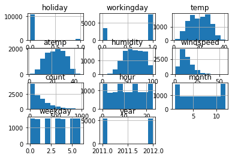

```python
# View histogram of all features again now with the hour feature
train.hist()
```

```python
#only used after training this predictor later in the notebook
# Feature importance in our model features
predictor_new_features.feature_importance(train)
```

```
Computing feature importance via permutation shuffling for 13 features using 5000 rows with 5 shuffle sets...
	2797.12s	= Expected runtime (559.42s per shuffle set)
	2259.08s	= Actual runtime (Completed 5 of 5 shuffle sets)
```

|  | importance | stddev | p_value | n | p99_high | p99_low |
| --- | --- | --- | --- | --- | --- | --- |
| hour | 155.347913 | 1.528851 | 1.125548e-09 | 5 | 158.495839 | 152.199988 |
| datetime | 86.126036 | 0.967311 | 1.909124e-09 | 5 | 88.117742 | 84.134330 |
| workingday | 40.007178 | 1.350064 | 1.553775e-07 | 5 | 42.786978 | 37.227377 |
| humidity | 17.195397 | 0.843132 | 6.913896e-07 | 5 | 18.931416 | 15.459377 |
| temp | 14.100505 | 0.611971 | 4.246943e-07 | 5 | 15.360562 | 12.840448 |
| year | 11.209427 | 0.355064 | 1.206403e-07 | 5 | 11.940508 | 10.478346 |
| weekday | 10.359561 | 0.146756 | 4.831508e-09 | 5 | 10.661734 | 10.057388 |
| atemp | 9.757678 | 0.558211 | 1.279665e-06 | 5 | 10.907042 | 8.608314 |
| weather | 8.389170 | 0.619575 | 3.544289e-06 | 5 | 9.664884 | 7.113456 |
| month | 2.338091 | 0.195862 | 5.854420e-06 | 5 | 2.741374 | 1.934809 |
| windspeed | 2.057008 | 0.126734 | 1.720350e-06 | 5 | 2.317955 | 1.796060 |
| season | 1.794911 | 0.152220 | 6.148180e-06 | 5 | 2.108335 | 1.481488 |
| holiday | 0.755254 | 0.167234 | 2.705419e-04 | 5 | 1.099591 | 0.410917 |

## Step 5: Rerun the model with the same settings as before, just with more features

```python
predictor_new_features = TabularPredictor(label='count', eval_metric='root_mean_squared_error').fit(train, time_limit=600, presets='best_quality')
```

[output not shown]

[output cut: 69 more lines]

```
	Fitting 8 child models (S1F1 - S1F8) | Fitting with ParallelLocalFoldFittingStrategy
	-30.4813	 = Validation score   (-root_mean_squared_error)
	69.47s	 = Training   runtime
	0.19s	 = Validation runtime
Fitting model: ExtraTreesMSE_BAG_L2 ... Training model for up to 0.45s of the 0.43s of remaining time.
	-31.4378	 = Validation score   (-root_mean_squared_error)
	11.77s	 = Training   runtime
	0.75s	 = Validation runtime
Completed 1/20 k-fold bagging repeats ...
Fitting model: WeightedEnsemble_L3 ... Training model for up to 360.0s of the -13.0s of remaining time.
	-30.104	 = Validation score   (-root_mean_squared_error)
	0.32s	 = Training   runtime
	0.0s	 = Validation runtime
AutoGluon training complete, total runtime = 613.4s ... Best model: "WeightedEnsemble_L3"
TabularPredictor saved. To load, use: predictor = TabularPredictor.load("AutogluonModels/ag-20220724_172718/")
```

```python
predictor_new_features.fit_summary()
```

```
*** Summary of fit() ***
Estimated performance of each model:
                     model   score_val  pred_time_val    fit_time  pred_time_val_marginal  fit_time_marginal  stack_level  can_infer  fit_order
0      WeightedEnsemble_L3  -30.104012      20.618005  563.136905                0.001084           0.322633            3       True         15
1          LightGBM_BAG_L2  -30.441898      18.630708  425.367837                0.356307          26.780845            2       True         11
2          CatBoost_BAG_L2  -30.481312      18.459519  468.056602                0.185119          69.469611            2       True         13
3        LightGBMXT_BAG_L2  -31.097638      19.306815  429.932196                1.032414          31.345205            2       True         10
4     ExtraTreesMSE_BAG_L2  -31.437803      19.022321  410.354287                0.747921          11.767296            2       True         14
5   RandomForestMSE_BAG_L2  -31.459673      19.043080  435.218611                0.768680          36.631620            2       True         12
6      WeightedEnsemble_L2  -32.146355      16.920680  352.781485                0.001161           0.680000            2       True          9
7          LightGBM_BAG_L1  -33.917582       3.193370   45.645372                3.193370          45.645372            1       True          4
8          CatBoost_BAG_L1  -34.152610       0.246382  198.118800                0.246382         198.118800            1       True          6
9        LightGBMXT_BAG_L1  -34.376007      12.682507   91.698997               12.682507          91.698997            1       True          3
10    ExtraTreesMSE_BAG_L1  -38.060756       0.685790    7.349008                0.685790           7.349008            1       True          7
11  RandomForestMSE_BAG_L1  -38.447602       0.691014   16.598924                0.691014          16.598924            1       True          5
12   KNeighborsDist_BAG_L1  -84.125061       0.106245    0.039392                0.106245           0.039392            1       True          2
13   KNeighborsUnif_BAG_L1 -101.546199       0.104098    0.041942                0.104098           0.041942            1       True          1
14  NeuralNetFastAI_BAG_L1 -103.104803       0.564994   39.094557                0.564994          39.094557            1       True          8
Number of models trained: 15
Types of models trained:
{'WeightedEnsembleModel', 'StackerEnsembleModel_CatBoost', 'StackerEnsembleModel_LGB', 'StackerEnsembleModel_XT', 'StackerEnsembleModel_NNFastAiTabular', 'StackerEnsembleModel_RF', 'StackerEnsembleModel_KNN'}
Bagging used: True  (with 8 folds)
Multi-layer stack-ensembling used: True  (with 3 levels)
Feature Metadata (Processed):
(raw dtype, special dtypes):
('category', [])             : 2 | ['season', 'weather']
('float', [])                : 3 | ['temp', 'atemp', 'windspeed']
('int', [])                  : 4 | ['humidity', 'hour', 'month', 'weekday']
('int', ['bool'])            : 3 | ['holiday', 'workingday', 'year']
('int', ['datetime_as_int']) : 5 | ['datetime', 'datetime.year', 'datetime.month', 'datetime.day', 'datetime.dayofweek']
Plot summary of models saved to file: AutogluonModels/ag-20220724_172718/SummaryOfModels.html
*** End of fit() summary ***
```

[output not shown]

[output cut: 139 more lines]

```
  'CatBoost_BAG_L2': 'StackerEnsembleModel_CatBoost',
  'ExtraTreesMSE_BAG_L1': 'StackerEnsembleModel_XT',
  'ExtraTreesMSE_BAG_L2': 'StackerEnsembleModel_XT',
  'KNeighborsDist_BAG_L1': 'StackerEnsembleModel_KNN',
  'KNeighborsUnif_BAG_L1': 'StackerEnsembleModel_KNN',
  'LightGBMXT_BAG_L1': 'StackerEnsembleModel_LGB',
  'LightGBMXT_BAG_L2': 'StackerEnsembleModel_LGB',
  'LightGBM_BAG_L1': 'StackerEnsembleModel_LGB',
  'LightGBM_BAG_L2': 'StackerEnsembleModel_LGB',
  'NeuralNetFastAI_BAG_L1': 'StackerEnsembleModel_NNFastAiTabular',
  'RandomForestMSE_BAG_L1': 'StackerEnsembleModel_RF',
  'RandomForestMSE_BAG_L2': 'StackerEnsembleModel_RF',
  'WeightedEnsemble_L2': 'WeightedEnsembleModel',
  'WeightedEnsemble_L3': 'WeightedEnsembleModel'},
 'num_bag_folds': 8}
```

```python
# Remember to set all negative values to zero
predictions = predictor_new_features.predict_proba(test)
predictions[predictions < 0] = 0
predictions.describe()
```

```
count    6493.000000
mean      150.223221
std       129.471756
min         2.320288
25%        56.388130
50%       115.698601
75%       204.295807
max       806.175598
Name: count, dtype: float64
```

```python
# Same submitting predictions
submission_new_features = pd.read_csv('sampleSubmission.csv')
submission_new_features["count"] = predictions
submission_new_features.to_csv("submission_new_features.csv", index=False)
```

```python
!kaggle competitions submit -c bike-sharing-demand -f submission_new_features.csv -m "new features tested"
```

```
100% 188k/188k [00:01<00:00, 101kB/s]
Successfully submitted to Bike Sharing Demand
```

```python
!kaggle competitions submissions -c bike-sharing-demand | tail -n +1 | head -n 6
```

```
fileName                     date                 description                            status    publicScore  privateScore
---------------------------  -------------------  -------------------------------------  --------  -----------  ------------
submission_new_features.csv  2022-07-24 19:24:40  new features tested                    complete  0.71000      0.71000
submission_new_features.csv  2022-07-24 17:10:46  new features tested                    complete  1.92656      1.92656
submission2.csv              2022-07-23 19:37:32  second raw submission                  complete  1.89135      1.89135
submission_new_features.csv  2022-07-23 19:08:16  new features tested                    complete  1.97037      1.97037
```

#### New Score of 0.7100

## Step 6: Hyper parameter optimization

- There are many options for hyper parameter optimization.
- Options are to change the AutoGluon higher level parameters or the individual model hyperparameters.
- The hyperparameters of the models themselves that are in AutoGluon. Those need the `hyperparameter` and `hyperparameter_tune_kwargs` arguments.

```python
import autogluon.core as ag
nn_options = {
    'num_epochs': 5,
    'learning_rate': ag.space.Real(1e-4, 1e-2, default=5e-4, log=True),
    'activation': ag.space.Categorical('relu', 'softrelu', 'tanh'),
    'layers': ag.space.Categorical([100], [1000], [200, 100], [300, 200, 100]),
    'dropout_prob': ag.space.Real(0.0, 0.5, default=0.1),
}

gbm_options = {
    'num_boost_round': 100,
    'num_leaves': ag.space.Int(lower=26, upper=66, default=36),
}

hyperparameters = {  # hyperparameters of each model type
                   'GBM': gbm_options,
                   'NN': nn_options,
                  }

hyperparameter_tune_kwargs = {
    'scheduler' : 'local',
    'searcher': 'auto',
}
predictor_new_hpo = TabularPredictor(label='count').fit(train, time_limit=600, presets='best_quality', auto_stack='True',
 hyperparameters=hyperparameters, hyperparameter_tune_kwargs=hyperparameter_tune_kwargs)
```

[output not shown]

[output cut: 65 more lines]

```
	-31.4866	 = Validation score   (-root_mean_squared_error)
	37.62s	 = Training   runtime
	0.76s	 = Validation runtime
Fitting model: CatBoost_BAG_L2 ... Training model for up to 63.1s of the 63.06s of remaining time.
	Fitting 8 child models (S1F1 - S1F8) | Fitting with ParallelLocalFoldFittingStrategy
	-30.3859	 = Validation score   (-root_mean_squared_error)
	60.93s	 = Training   runtime
	0.11s	 = Validation runtime
Completed 1/20 k-fold bagging repeats ...
Fitting model: WeightedEnsemble_L3 ... Training model for up to 360.0s of the -1.29s of remaining time.
	-30.1154	 = Validation score   (-root_mean_squared_error)
	0.25s	 = Training   runtime
	0.0s	 = Validation runtime
AutoGluon training complete, total runtime = 601.61s ... Best model: "WeightedEnsemble_L3"
TabularPredictor saved. To load, use: predictor = TabularPredictor.load("AutogluonModels/ag-20220724_193220/")
```

```python
predictor_new_hpo.fit_summary()
predictor_new_hpo.leaderboard(silent=True)
```

[output not shown]

[output not shown]

```python
# Remember to set all negative values to zero
predictions = predictor_new_hpo.predict_proba(test)
predictions[predictions < 0] = 0
predictions.describe()
```

```
count    6493.000000
mean      153.435455
std       133.139420
min         2.627350
25%        54.431137
50%       117.928520
75%       212.907578
max       805.353149
Name: count, dtype: float64
```

```python
# Same submitting predictions
submission_new_hpo = pd.read_csv('sampleSubmission.csv')
submission_new_hpo["count"] = predictions
submission_new_hpo.to_csv("submission_new_hpo.csv", index=False)
```

```python
!kaggle competitions submit -c bike-sharing-demand -f submission_new_hpo.csv -m "New features with hyperparameters"
```

```
100% 188k/188k [00:02<00:00, 72.8kB/s]
Successfully submitted to Bike Sharing Demand
```

```python
!kaggle competitions submissions -c bike-sharing-demand | tail -n +1 | head -n 6
```

```
fileName                     date                 description                            status    publicScore  privateScore
---------------------------  -------------------  -------------------------------------  --------  -----------  ------------
submission_new_hpo.csv       2022-07-24 19:45:09  New features with hyperparameters      complete  0.67855      0.67855
submission_new_hpo.csv       2022-07-24 19:31:28  New features with hyperparameters      complete  0.45152      0.45152
submission_new_features.csv  2022-07-24 19:24:40  new features tested                    complete  0.71000      0.71000
submission_new_features.csv  2022-07-24 17:10:46  new features tested                    complete  1.92656      1.92656
```